# Neighborhoods of Hamburg - Which one is for you? {-}

Capstone project for Coursera course [Applied Data Science Capstone](https://www.coursera.org/learn/applied-data-science-capstone/home/welcome)

*By Nima Mehrafshan*

Hamburg, 7 October 2019

# The Business Problem

Deciding which neighborhood to live in or where to buy property is a difficult task, especially if you don't know the ins and outs of the city you're looking at. There are so many factors that may influence your decision and the factors may be different for each decision maker depending on their goals, tastes, preferences and individual situation. Those factors may include the accessibility of the location, distance and quality of schools, the availability of restaurants and cafés, property prices and expectations of future development, the type of people you typically meet in the area, and so on. In this project, I'd like to explore the 104 neighborhoods of my home town Hamburg (Germany), and see how data could help to make decisions like that.

I will take the position of a home buyer here because I think everyone can relate to their decision situation. But I think the same analysis would also be relevant to an investor or even to the city administration, who could use it to support their urban development decisions.

So the main questions, I will try to answer are:

1. What are the main drivers of real estate prices in Hamburg?
2. Which neighborhoods are undervalued, when relating their attributes to current average property prices?
3. How can neighborhoods be characterized? Can the 100+ neighborhoods be clustered by similarity into a managable number of groups, in order to get a quick understanding of what they are like?

# Research Outline

1) To answer question one I will estimate a random forest model with property price levels as the target and the socio-economics as well as the points-of-interest as features (hedonic pricing model). I will then extract the importances from the model to identify the main drivers of property prices in Hamburg. The direction of the relationship From can then be derived from the correlations of these features with the price levels.

2) For question two I will predict price levels for all neighborhoods using the model from above and use the residuals as an indicator of under or overvaluation.

3) I will use the relevant features derived in 1) to run a KMeans cluster analysis and then characterize the resulting clusters based on the most prevalent differences of the clusters compared with the city average.

# Data

I will need data about average prices in the neighborhoods and about as many neighborhood characteristics as possible. I found three main data sources that I will deploy in the analysis:

- Socio-economic data from [Statistikamt Nord](https://www.statistik-nord.de), the statistics office for the Bundesländer (German states) Hamburg and Schleswig-Holstein. They provide over 70 socio-economic variables for the years 2013 - 2017, including average household income, number of schools (by type of school), average household size, unemployment rates, and many more. The data set also includes *average property prices per m²* !
- Points of interest from the [Foursquare API](https://developer.foursquare.com), such as restaurants, grocery stoes, nightlife venues, etc.
- The borders of the Hamburg neighborhoods in a digital format from the land surveying office ([Landesbetrieb Geoinformation und Vermessung](https://www.hamburg.de/bsw/landesbetrieb-geoinformation-und-vermessung)), which I will use for plotting and to link the Foursquare venues to the neighborhoods.

## Data Acquisition

### Neighborhood Shapes

To get the neighborhood shapes I am using the [WFS service](https://en.wikipedia.org/wiki/Web_Feature_Service) of the land surveying office, transform it into a GeoDataFrame and store the result in a geoJSON file.

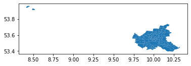

The plot shows that the exclave neighborhood "Neuwerk" is included in the data. Even though it legally belongs to Hamburg, it has litte relevance with only ~50 inhabitants, so I am removing it:

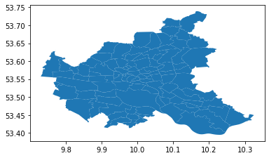

### Socio-economic Data

Next I get the socio-economic data from the statistics office. It is provided as Excel files. I wrote a function `import_socioecon_data` that takes care of a number of things:

- Downloading the files and reading the data
- Storing meta data, such as the source variable names and descriptions, into a file
- Translating the variable names and descriptions to English using the Google Translator API
- Reading in the meta data file if the function is being run a second time and using the variable names that I have edited in the meantime
- Merging the data from the different files
- Specifying the administrative levels (the data contains data on neighborhoods, city districts and the city as a whole)
- Saving the data as a pickle file

Here are the first few lines:

|  | name | area_in_km2 | average_apartment_price_per_m2 | average_house_price_per_m2 | average_household_size | average_income | average_land_price_per_m2 | average_living_space_m2 | births | car_density | ... | students_in_secondary_schools | taxpayers | unemployed_population | unemployed_population_pct | welfare_receivers | welfare_receivers_pct | year | youth_unemployed | youth_unemployment_pct | admin_level |
| --- | --- | --- | --- | --- | --- | --- | --- | --- | --- | --- | --- | --- | --- | --- | --- | --- | --- | --- | --- | --- | --- |
| 0 | Hamburg-Altstadt | 1.300347 | 5710.0 | NaN | 1.592838 | 31336 | NaN | 73.389302 | 46 | 272.885033 | ... | 61 | 1952 | 98 | 5.441421 | 244 | 10.585683 | 2017 | 8.0 | 4.733728 | 10 |
| 1 | HafenCity | 2.425612 | 7958.0 | NaN | 2.115759 | 93206 | NaN | 92.797023 | 68 | 264.681555 | ... | 138 | 1255 | 86 | 3.300077 | 487 | 13.427075 | 2017 | 11.0 | 3.197674 | 10 |
| 2 | Neustadt | 2.261902 | 5081.0 | NaN | 1.498001 | 34521 | NaN | 63.007217 | 152 | 246.167152 | ... | 400 | 7015 | 504 | 5.236364 | 969 | 7.618523 | 2017 | 26.0 | 2.546523 | 10 |
| 3 | St. Pauli | 2.242488 | 5991.0 | NaN | 1.532348 | 27977 | 1316.0 | 64.234276 | 239 | 194.213591 | ... | 818 | 11066 | 1316 | 7.420355 | 2987 | 13.274966 | 2017 | 60.0 | 3.186405 | 10 |
| 4 | St. Georg | 1.822657 | 5169.0 | NaN | 1.515055 | 44121 | 2179.0 | 71.089805 | 116 | 208.050656 | ... | 299 | 5683 | 427 | 4.909739 | 819 | 7.408412 | 2017 | 25.0 | 2.149613 | 10 |

5 rows × 79 columns

### Points of interest

Now to the Foursquare API. I went through the list of Foursquare's venue categories and selected those I thought of being particularly relevant for buyers of apartments or houses. I grouped those categories into six topics:

- Groceries
  - Supermarket
  - Grocery Store
  - Organic Grocery
- Education
  - High School
  - Middle School
  - Child Care Service
  - Playground
- Health
  - Physical Therapist
  - Doctor's Office
- Public Transportation
  - Bus Stop
  - Light Rail Station
  - Metro Station
  - Train Station
- Gastronomy
  - Food
- Nightlife
  - Nightlife Spot

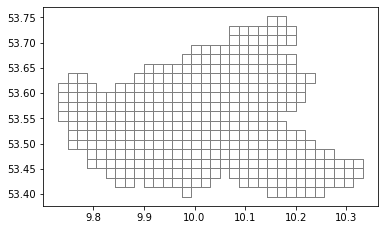

After running the function to get the venues let's create a DataFrame with all venues, spatially merge it with the neighborhood shapes, and plot them:

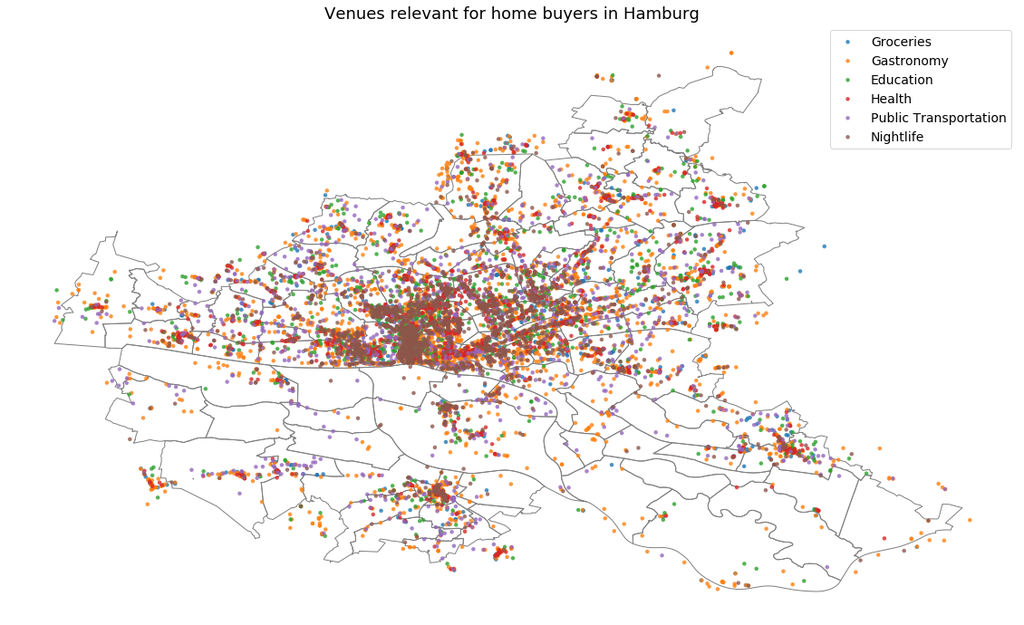

## Data preparation

The socio-economics data is in long format with a row for each year of data for every neighborhood:

|  | name | year | area_in_km2 | average_apartment_price_per_m2 | average_apartment_size_m2 | average_house_price_per_m2 | average_household_size | average_income | average_land_price_per_m2 | births | ... | students_in_comprehensive_schools_pct | students_in_gymnasiums_pct | students_in_secondary_schools | taxpayers | unemployed_population | unemployed_population_pct | welfare_receivers | welfare_receivers_pct | youth_unemployed | youth_unemployment_pct |
| --- | --- | --- | --- | --- | --- | --- | --- | --- | --- | --- | --- | --- | --- | --- | --- | --- | --- | --- | --- | --- | --- |
| 506 | Allermöhe | 2013 | 8.65 | NaN | 114.71 | 2126.0 | 2.10 | 35822 | 169.0 | 10 | ... | 53.90 | 44.90 | 89 | 653 | 22 | 2.40 | 29 | 2.20 | 3.0 | 2.10 |
| 399 | Allermöhe | 2014 | 8.65 | NaN | 115.41 | 2287.0 | 2.08 | 35822 | 187.0 | 7 | ... | 56.18 | 40.45 | 89 | 653 | 23 | 2.50 | 27 | 2.00 | NaN | NaN |
| 292 | Allermöhe | 2015 | 8.65 | 2351.0 | 115.41 | 2270.0 | 2.06 | 35822 | 164.0 | 7 | ... | 67.03 | 30.77 | 91 | 653 | 25 | 2.63 | 26 | 1.88 | 3.0 | 1.64 |
| 185 | Allermöhe | 2016 | 8.64 | NaN | 115.19 | 2548.0 | 2.09 | 38369 | 203.0 | 9 | ... | 61.45 | 36.14 | 83 | 696 | 17 | 1.84 | 34 | 2.50 | 0.0 | 0.00 |
| 78 | Allermöhe | 2017 | 8.64 | 3128.0 | 114.85 | 2751.0 | 2.06 | 38369 | 226.0 | 10 | ... | 57.14 | 41.56 | 77 | 696 | 21 | 2.27 | 17 | 1.25 | 3.0 | 2.04 |

5 rows × 78 columns

For the following analyses, I'm reshaping it to wide format with one column for each year and variable:

| name | area_in_km2_y2013 | area_in_km2_y2014 | area_in_km2_y2015 | area_in_km2_y2016 | area_in_km2_y2017 | average_apartment_price_per_m2_y2013 | average_apartment_price_per_m2_y2014 | average_apartment_price_per_m2_y2015 | average_apartment_price_per_m2_y2016 | average_apartment_price_per_m2_y2017 | ... | youth_unemployed_y2013 | youth_unemployed_y2014 | youth_unemployed_y2015 | youth_unemployed_y2016 | youth_unemployed_y2017 | youth_unemployment_pct_y2013 | youth_unemployment_pct_y2014 | youth_unemployment_pct_y2015 | youth_unemployment_pct_y2016 | youth_unemployment_pct_y2017 |
| --- | --- | --- | --- | --- | --- | --- | --- | --- | --- | --- | --- | --- | --- | --- | --- | --- | --- | --- | --- | --- | --- |
| Allermöhe | 8.65 | 8.65 | 8.65 | 8.64 | 8.64 | NaN | NaN | 2351.0 | NaN | 3128.0 | ... | 3.0 | NaN | 3.0 | 0.0 | 3.0 | 2.1 | NaN | 1.64 | 0.00 | 2.04 |
| Alsterdorf | 3.06 | 3.06 | 3.06 | 3.16 | 3.16 | 3239.0 | 3747.0 | 3891.0 | 4261.0 | 4486.0 | ... | 18.0 | 25.0 | 17.0 | 27.0 | 32.0 | 1.4 | 1.81 | 1.21 | 1.82 | 2.03 |
| Altengamme | 15.61 | 15.61 | 15.61 | 15.61 | 15.61 | NaN | NaN | NaN | NaN | NaN | ... | 3.0 | 8.0 | 4.0 | 4.0 | 0.0 | 1.3 | 3.27 | 1.68 | 1.68 | 0.00 |
| Altona-Altstadt | 2.75 | 2.75 | 2.75 | 2.72 | 2.72 | 4022.0 | 4053.0 | 4911.0 | 5745.0 | 6064.0 | ... | 102.0 | 120.0 | 110.0 | 101.0 | 112.0 | 4.0 | 4.68 | 4.39 | 3.98 | 4.29 |
| Altona-Nord | 2.18 | 2.18 | 2.18 | 2.22 | 2.22 | 4022.0 | 4053.0 | 4911.0 | 5745.0 | 6064.0 | ... | 79.0 | 59.0 | 72.0 | 66.0 | 61.0 | 3.9 | 2.94 | 3.58 | 3.29 | 2.91 |

5 rows × 332 columns

As it turns out, there are some 700+ missing values in the data:

```
Missing values: 739 (0.02%) of 32868
```

I use the iterative imputation of sklearn to predict the missing values based on all available data.

```
Missing values: 0 (0.0%) of 32868
```

Most variables in the dataset are available in absolute terms and as a percentage of some base, e. g. the population under 15 on welfare (`population_under_15_on_welfare`) and the population under 15 on welfare as a percentage of the total population (`population_under_15_on_welfare_pct`). And after the reshape, there is now a column for each year. To simplify the dataset, I will calculate a 5 year change for all absolute variables and then drop them. I will also drop all but the 2017 versions of the variables.

| name | area_in_km2 | average_apartment_price_per_m2 | average_apartment_size_m2 | average_house_price_per_m2 | average_household_size | average_income | average_land_price_per_m2 | births | car_density | deaths | ... | residential_buildings_5y_chg_pct | serviced_apartments_5y_chg_pct | single_households_5y_chg_pct | singleparent_households_5y_chg_pct | social_housing_units_5y_chg_pct | students_in_secondary_schools_5y_chg_pct | taxpayers_5y_chg_pct | unemployed_population_5y_chg_pct | welfare_receivers_5y_chg_pct | youth_unemployed_5y_chg_pct |
| --- | --- | --- | --- | --- | --- | --- | --- | --- | --- | --- | --- | --- | --- | --- | --- | --- | --- | --- | --- | --- | --- |
| Allermöhe | 8.637358 | 3128.000000 | 114.851852 | 2751.000000 | 2.059880 | 38369.0 | 226.0 | 10.0 | 559.882439 | 16.0 | ... | 100.562500 | 70.428571 | 113.102564 | 91.307692 | 100.000000 | 85.516854 | 105.584992 | 94.454545 | 57.620690 | 99.000000 |
| Alsterdorf | 3.155241 | 4486.000000 | 77.606108 | 6451.000000 | 1.806265 | 52426.0 | 886.0 | 168.0 | 346.550462 | 157.0 | ... | 102.207450 | 133.408602 | 107.285643 | 99.279330 | 80.440443 | 103.685212 | 96.569283 | 113.369501 | 148.662618 | 176.777778 |
| Altengamme | 15.608172 | 2718.152032 | 107.537954 | 2183.000000 | 2.226155 | 47341.0 | 230.0 | 19.0 | 565.449688 | 30.0 | ... | 100.740506 | 11.500000 | 107.360129 | 86.931034 | 99.000000 | 81.035928 | 98.624060 | 99.000000 | 84.000000 | -1.000000 |
| Altona-Altstadt | 2.717873 | 6064.000000 | 63.313431 | 6094.660447 | 1.652749 | 30833.0 | 1465.0 | 390.0 | 228.101197 | 211.0 | ... | 100.833123 | 428.411765 | 100.689736 | 97.913043 | 79.977312 | 105.902502 | 104.151065 | 94.781638 | 90.348343 | 108.803922 |
| Altona-Nord | 2.217817 | 6064.000000 | 63.919232 | 5912.707922 | 1.651354 | 29901.0 | 1153.0 | 331.0 | 225.137279 | 113.0 | ... | 100.845343 | 100.000000 | 100.590250 | 99.153846 | 92.212036 | 99.526316 | 100.139252 | 91.903752 | 98.382716 | 76.215190 |

5 rows × 102 columns

To merge the socio-economic data with the shapes, I can only use the neighborhood names as keys. So, let's first check out if there are any differences in the names:

```
Columns in shapes not in data: Neuland, Steinwerder, Neuwerk, Kleiner Grasbrook, Finkenwerder, St.Pauli, Altenwerder, St.Georg, Waltershof, Moorburg, Gut Moor
```

```
Columns in data not in shapes: Waltershof und Finkenwerder, Kleiner Grasbrook und Steinwerder, St. Georg, St. Pauli, Neuland und Gut Moor, Moorburg und Altenwerder
```

The statistics office apparently has merged some neighborhoods with low populations. Moreover, in the shapes data, there are no spaces after the "." in "St.Georg" and "St. Pauli". So I fix those difference and merge the neighborhoods also in the shapes dataset.

|  | name | district | geometry |
| --- | --- | --- | --- |
| 97 | Wilstorf | Harburg | MULTIPOLYGON (((9.97677 53.44140, 9.97640 53.4... |
| 98 | Kleiner Grasbrook und Steinwerder | Hamburg-Mitte | MULTIPOLYGON (((9.97670 53.52761, 9.97669 53.5... |
| 99 | Moorburg und Altenwerder | Harburg | MULTIPOLYGON (((9.88750 53.49915, 9.88750 53.4... |
| 100 | Neuland und Gut Moor | Harburg | MULTIPOLYGON (((10.00506 53.47249, 10.00651 53... |
| 101 | Waltershof und Finkenwerder | Hamburg-Mitte | MULTIPOLYGON (((9.90308 53.54164, 9.91310 53.5... |

Now we can go ahead and merge the two datasets:

Next, we use the venues data to create a DataFrame containing the count of venues of each *topic* (see above) per neighborhood.

| name | education_venues | gastronomy_venues | groceries_venues | health_venues | nightlife_venues | public_transportation_venues |
| --- | --- | --- | --- | --- | --- | --- |
| Allermöhe | 0.0 | 2.0 | 0.0 | 0.0 | 2.0 | 1.0 |
| Alsterdorf | 7.0 | 29.0 | 6.0 | 13.0 | 5.0 | 11.0 |
| Altengamme | 0.0 | 4.0 | 0.0 | 1.0 | 1.0 | 0.0 |
| Altona-Altstadt | 20.0 | 64.0 | 20.0 | 62.0 | 41.0 | 28.0 |
| Altona-Nord | 16.0 | 45.0 | 12.0 | 15.0 | 25.0 | 76.0 |

Finally, we merge these venue counts with the socio-economics data and generade a table of summary statistics (only first and last 5 columns here for brevity).

|  | count | mean | std | min | 25% | 50% | 75% | max |
| --- | --- | --- | --- | --- | --- | --- | --- | --- |
| area_in_km2 | 99.0 | 7.79 | 7.00 | 0.55 | 2.73 | 5.95 | 9.95 | 35.39 |
| average_apartment_price_per_m2 | 99.0 | 3762.55 | 1322.55 | 2107.00 | 2805.00 | 3265.00 | 4494.00 | 8560.00 |
| average_apartment_size_m2 | 99.0 | 84.26 | 19.89 | 50.59 | 69.84 | 78.42 | 98.53 | 143.60 |
| average_house_price_per_m2 | 99.0 | 4083.90 | 1513.93 | 2107.00 | 2793.84 | 3696.00 | 5192.30 | 8416.00 |
| average_household_size | 99.0 | 1.88 | 0.26 | 1.30 | 1.66 | 1.89 | 2.09 | 2.73 |
| ... | ... | ... | ... | ... | ... | ... | ... | ... |
| gastronomy_venues | 99.0 | 49.25 | 49.93 | 0.00 | 12.50 | 33.00 | 62.00 | 212.00 |
| groceries_venues | 99.0 | 8.43 | 7.61 | 0.00 | 2.50 | 7.00 | 12.50 | 33.00 |
| health_venues | 99.0 | 15.26 | 17.30 | 0.00 | 3.00 | 9.00 | 22.50 | 73.00 |
| nightlife_venues | 99.0 | 19.62 | 32.21 | 0.00 | 2.00 | 8.00 | 23.50 | 220.00 |
| public_transportation_venues | 99.0 | 13.30 | 12.21 | 0.00 | 4.50 | 11.00 | 17.00 | 76.00 |

108 rows × 8 columns

The following map shows prices per m² for apartments accross the neighborhoods of Hamburg.

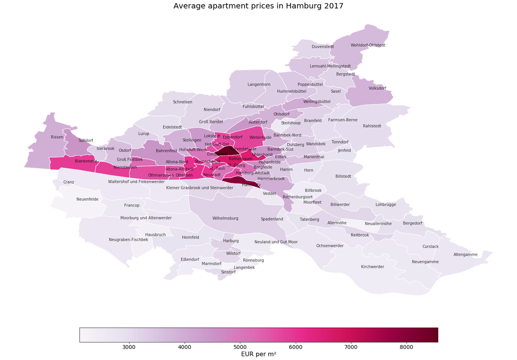

# Methodology and Analysis

In this section I will conduct the actual analysis. I start with deriving the main drivers of property prices.

## Main drivers of property prices

The data contains three property price variables:

- Average price per m² of apartments (condos)
- Average price per m² of houses (detached and semi-detached)
- Average price per m² of building land

In some neighborhoods one type of property is more prevalent than the other. In order to have a single target variable, I will reduce these three variables to one using Principal Component Analysis (PCA) and call it *property price level*. Before doing that I will standardize the data ($\mu=0$, $\sigma=1$).

nb. I am dropping the area of the neighborhood because it is not a very actionable variable.

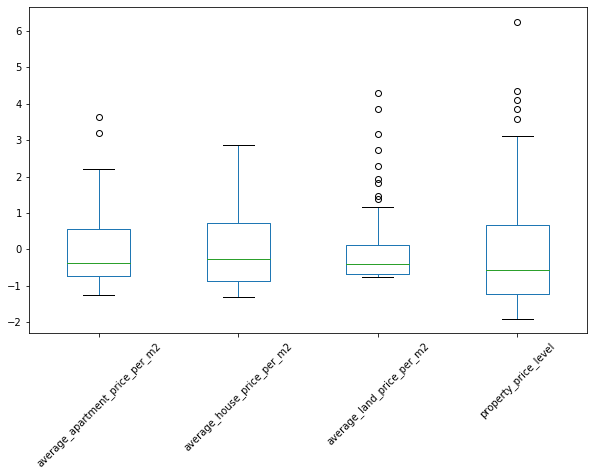

Now, let's estimate a random forest model to derive feature importances. I will use 5-fold cross validation to tune the main parameters of the models and use the *Mean Squared Error* as the cost function.

```
The model's R² is: 0.9532
```

From the model we can extract an importance measure that I plot here in descending order, to answer question one from above.

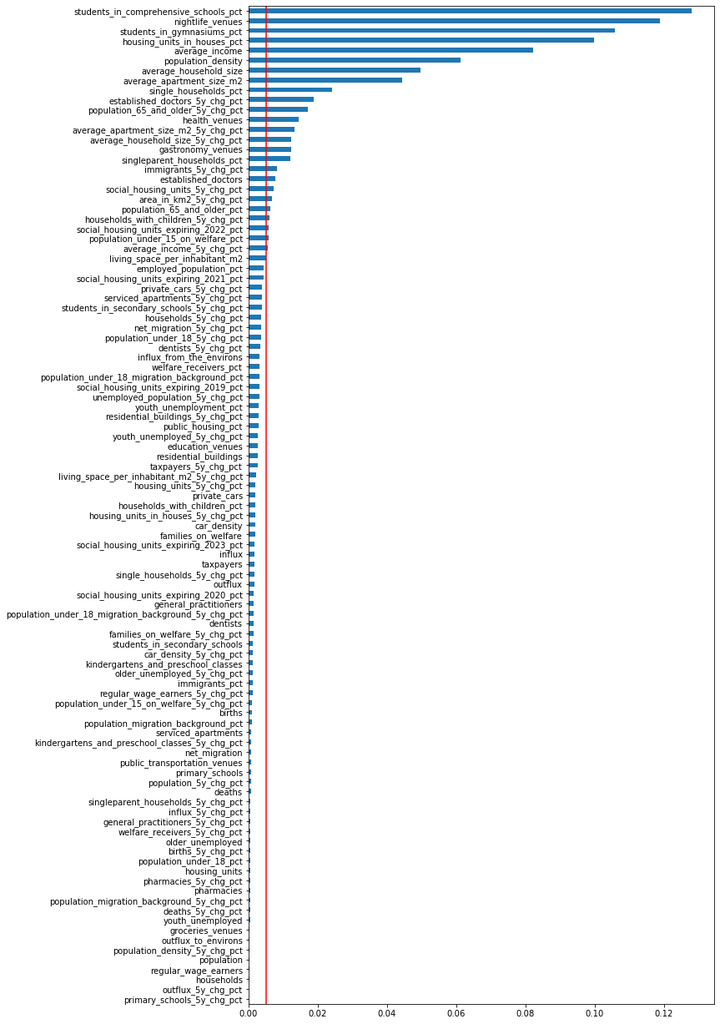

Clearly, only a few variables have a substantial influence on prices. Going down the sorted list, importances quickly drop to very low values. Interestingly, the distribution of students across the two main types of schools (comprehensive vs. Gymnasium), the most advanced type of German secondary schools) seems to be very important, followed by the number of nightlife venues, the proportion of detached and semi-detached houses vs. apartments, population density, average household size and income.

For the cluster analysis in the next section, I will only use features with an importance score of at least 0.005 (see red line).

Now, to see the direction of the effects of these 26 features, let's generate a correlation matrix.

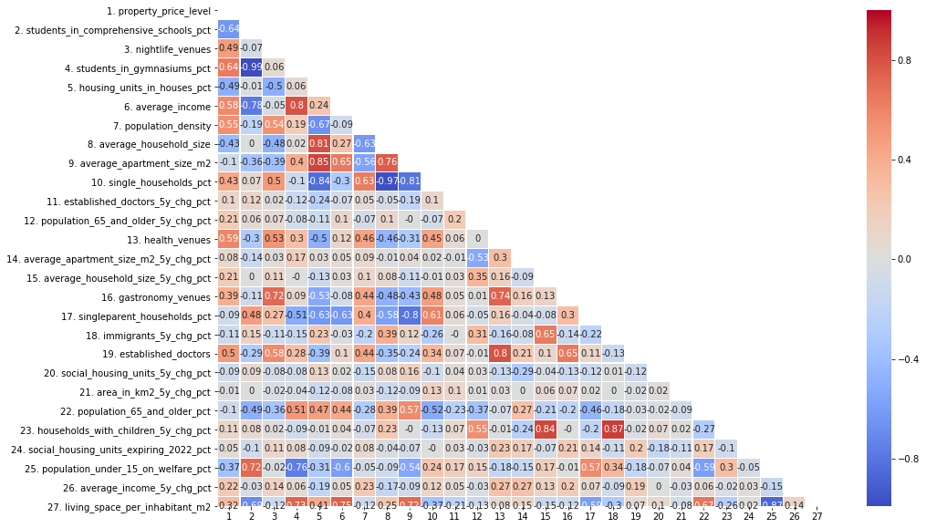

The first column shows the correlations of all neighborhood features with the price level. The highest positive correlations are percentage of students in Gymnasiums, number of health venues, and average income. The highest negative correlations are the percentage of students in comprehensive schools, the percentage of houses vs. apartments, and average household size.

## Undervalued neighborhoods

To find out which neighborhoods are rather expensive and which are not in relation to their characteristics, I calculate the residuals of the random forest model, i.e. the difference between the predicted prices and the actual ones. In the plot, those neighborhoods that are undervalued according to the model (price estimate is higher than actual price) are displayed in darker shades of red.

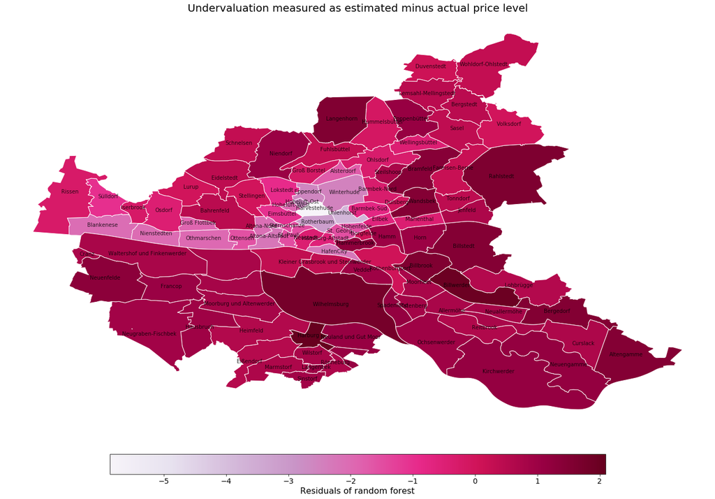

Let's list the top five undervalued neighborhoods.

| name | resid | average_apartment_price_per_m2 | average_house_price_per_m2 | average_land_price_per_m2 | average_apartment_price_per_m2_5y_chg_pct | average_house_price_per_m2_5y_chg_pct | average_land_price_per_m2_5y_chg_pct | average_price_per_m2 |
| --- | --- | --- | --- | --- | --- | --- | --- | --- |
| Harburg | 0.753160 | 3265.0 | 3075.0 | 286.0 | 165.751788 | 123.303239 | 109.852713 | 2208.666667 |
| Wellingsbüttel | 0.748222 | 4037.0 | 5196.0 | 856.0 | 135.754743 | 140.580381 | 134.657686 | 3363.000000 |
| Wilhelmsburg | 0.715014 | 3249.0 | 2810.0 | 231.0 | 149.473935 | 127.369118 | 159.416667 | 2096.666667 |
| Marmstorf | 0.441390 | 2480.0 | 2624.0 | 325.0 | 129.320547 | 124.790988 | 105.209150 | 1809.666667 |
| Steilshoop | 0.417820 | 2635.0 | 3112.0 | 441.0 | 163.790494 | 152.402065 | 121.160665 | 2062.666667 |

## Neighborhood clusters

### Cluster analysis

Finally, to answer question number 3, let's find out which neighborhoods are similar and how they can be grouped into clusters. Since some of the 26 features are highly correlated, I will deploy PCA once more in order to produce orthogonal variables. This time I will, however, not set the number of principal components to one, but let it be determined by the method of Minka [1] as implemented by sklearn, in order not to miss out on relevant variance.

[1]: Minka, T. P. “Automatic choice of dimensionality for PCA”. In NIPS, pp. 598-604

|  | 0 | 1 | 2 | 3 | 4 | 5 | 6 | 7 | 8 | 9 | ... | 14 | 15 | 16 | 17 | 18 | 19 | 20 | 21 | 22 | 23 |
| --- | --- | --- | --- | --- | --- | --- | --- | --- | --- | --- | --- | --- | --- | --- | --- | --- | --- | --- | --- | --- | --- |
| count | 99.000 | 99.000 | 99.000 | 99.000 | 99.000 | 99.000 | 99.000 | 99.000 | 99.000 | 99.000 | ... | 99.000 | 99.000 | 99.000 | 99.000 | 99.000 | 99.000 | 99.000 | 99.000 | 99.000 | 99.000 |
| mean | 0.000 | -0.000 | -0.000 | -0.000 | -0.000 | 0.000 | -0.000 | -0.000 | 0.000 | -0.000 | ... | -0.000 | -0.000 | 0.000 | -0.000 | 0.000 | 0.000 | -0.000 | -0.000 | -0.000 | 0.000 |
| std | 2.661 | 2.261 | 1.761 | 1.304 | 1.110 | 1.076 | 1.050 | 1.002 | 0.904 | 0.875 | ... | 0.558 | 0.514 | 0.465 | 0.437 | 0.426 | 0.329 | 0.254 | 0.236 | 0.153 | 0.102 |
| min | -5.307 | -5.839 | -4.155 | -4.394 | -3.220 | -3.336 | -2.560 | -2.459 | -2.268 | -2.438 | ... | -1.714 | -1.548 | -1.214 | -0.933 | -1.425 | -1.001 | -0.430 | -0.690 | -0.378 | -0.268 |
| 25% | -2.290 | -1.343 | -0.829 | -0.749 | -0.650 | -0.550 | -0.465 | -0.476 | -0.554 | -0.358 | ... | -0.294 | -0.269 | -0.293 | -0.292 | -0.236 | -0.138 | -0.161 | -0.157 | -0.087 | -0.064 |
| 50% | -0.121 | 0.138 | -0.324 | 0.016 | -0.081 | 0.044 | -0.086 | -0.051 | -0.027 | -0.048 | ... | 0.034 | 0.034 | 0.024 | -0.082 | 0.013 | -0.002 | -0.043 | 0.007 | -0.005 | -0.010 |
| 75% | 1.865 | 1.286 | 0.312 | 0.561 | 0.530 | 0.465 | 0.450 | 0.457 | 0.571 | 0.393 | ... | 0.245 | 0.343 | 0.288 | 0.262 | 0.247 | 0.147 | 0.108 | 0.154 | 0.083 | 0.070 |
| max | 6.149 | 9.402 | 11.566 | 6.992 | 3.487 | 6.423 | 5.707 | 3.100 | 2.316 | 3.831 | ... | 2.051 | 1.594 | 1.343 | 1.261 | 1.868 | 1.014 | 1.050 | 0.705 | 0.450 | 0.433 |

8 rows × 24 columns

### Discussion of the results

Let's now look at each of the resulting clusters and see what features are most different from the average of all neighborhood. I restrict the analysis to the top and bottom 5 features per cluster. I also add the mean of the average property price mer m² to the top of the table. Apart of the cluster mean, the table includes the difference to the grand mean of all neighborhoods in absolute terms and measured in standard deviations ( *Scaled Diff.* ). I'll try to be creative and give each cluster a suggestive name based on the results.

```
Neighborhoods: Hamburg-Altstadt, Hamm, Neustadt, St. Georg, Altona-Altstadt, Altona-Nord, Bahrenfeld, Sternschanze, Lokstedt, Stellingen, Barmbek-Nord, Barmbek-Süd, Dulsberg, Hohenfelde, Langenhorn, Bramfeld, Eilbek, Rahlstedt, Wandsbek, Bergedorf, Harburg
```

|  | Cluster Mean | Diff. Grand Mean | Scaled Diff. |
| --- | --- | --- | --- |
| average_price_per_m2 | 3181.39 | 300.76 | 0.26 |
| groceries_venues | 15.33 | 6.90 | 0.91 |
| single_households_pct | 61.54 | 10.82 | 0.91 |
| gastronomy_venues | 93.48 | 44.22 | 0.89 |
| public_transportation_venues | 23.95 | 10.65 | 0.88 |
| health_venues | 29.62 | 14.36 | 0.83 |
| population_under_18_pct | 13.85 | -3.00 | -0.77 |
| housing_units_in_houses_pct | 8.98 | -22.38 | -0.83 |
| households_with_children_pct | 14.48 | -4.60 | -0.84 |
| average_apartment_size_m2 | 67.04 | -17.22 | -0.87 |
| average_household_size | 1.64 | -0.24 | -0.92 |

The first cluster has many of the rather central, very popular neighborhoods with a high density of restaurants, shops, and doctors. It is dominated by 62% of single households and smaller apartments with 67 mliving area ² on average.

I'll name this cluster: *Single's paradise*

```
Neighborhoods: Iserbrook, Bergstedt, Allermöhe, Altengamme, Billwerder, Curslack, Kirchwerder, Moorfleet, Neuengamme, Ochsenwerder, Reitbrook, Spadenland, Tatenberg, Francop, Langenbek, Neuenfelde, Rönneburg, Sinstorf, Moorburg und Altenwerder, Neuland und Gut Moor
```

|  | Cluster Mean | Diff. Grand Mean | Scaled Diff. |
| --- | --- | --- | --- |
| average_price_per_m2 | 1938.19 | -942.44 | -0.82 |
| housing_units_in_houses_pct | 68.31 | 36.95 | 1.36 |
| car_density | 477.20 | 115.78 | 1.02 |
| average_household_size | 2.14 | 0.26 | 0.99 |
| average_apartment_size_m2 | 102.71 | 18.45 | 0.93 |
| households_with_children_pct | 23.18 | 4.11 | 0.75 |
| health_venues | 0.90 | -14.36 | -0.83 |
| gastronomy_venues | 5.80 | -43.45 | -0.87 |
| public_transportation_venues | 2.65 | -10.65 | -0.88 |
| groceries_venues | 1.00 | -7.43 | -0.98 |
| single_households_pct | 38.79 | -11.94 | -1.00 |

The second cluster is a lot cheaper than the average and includes more detached and semi-detached houses than apartments. It has a high car density, relatively many families with children and a low number of stores, restaurants or public transportation stops.

I'll name this cluster: *Low infrastructure Family*

```
Neighborhoods: Billbrook, Billstedt, Borgfelde, Horn, Rothenburgsort, Veddel, Wilhelmsburg, Lurup, Osdorf, Eidelstedt, Schnelsen, Ohlsdorf, Farmsen-Berne, Hummelsbüttel, Jenfeld, Steilshoop, Tonndorf, Lohbrügge, Neuallermöhe, Cranz, Eißendorf, Hausbruch, Heimfeld, Neugraben-Fischbek, Wilstorf, Klein…
```

|  | Cluster Mean | Diff. Grand Mean | Scaled Diff. |
| --- | --- | --- | --- |
| average_price_per_m2 | 2174.83 | -705.80 | -0.62 |
| population_under_18_migration_background_pct | 66.19 | 18.70 | 0.93 |
| population_migration_background_pct | 46.98 | 13.84 | 0.92 |
| population_under_15_on_welfare_pct | 31.20 | 12.54 | 0.87 |
| welfare_receivers_pct | 15.78 | 6.10 | 0.76 |
| students_in_district_schools_pct | 60.97 | 10.86 | 0.70 |
| average_apartment_size_m2 | 73.70 | -10.56 | -0.53 |
| average_income | 28281.44 | -13886.09 | -0.64 |
| living_space_per_inhabitant_m2 | 33.88 | -5.95 | -0.72 |
| students_in_secondary_schools_pct | 34.72 | -12.16 | -0.75 |

The third cluster consists of neighborhoods with high proportion of immigrants and welfare receivers and has a low average household income.

I'll name this cluster: *Immogrants and welfare*

```
Neighborhoods: HafenCity, Hammerbrook
```

|  | Cluster Mean | Diff. Grand Mean | Scaled Diff. |
| --- | --- | --- | --- |
| average_price_per_m2 | 4127.96 | 1247.33 | 1.09 |
| residential_buildings_5y_chg_pct | 132.73 | 30.68 | 6.31 |
| housing_units_5y_chg_pct | 158.54 | 55.07 | 6.18 |
| students_in_secondary_schools_5y_chg_pct | 406.24 | 296.75 | 5.81 |
| population_65_and_older_5y_chg_pct | 151.16 | 48.24 | 5.61 |
| taxpayers_5y_chg_pct | 130.31 | 29.12 | 5.54 |
| car_density | 195.43 | -165.99 | -1.47 |
| population_65_and_older_pct | 6.28 | -11.64 | -2.13 |
| living_space_per_inhabitant_m2_5y_chg_pct | 78.97 | -17.51 | -2.18 |
| car_density_5y_chg_pct | 72.49 | -24.02 | -2.89 |
| average_apartment_size_m2_5y_chg_pct | 92.32 | -6.91 | -4.90 |

The fourth cluster is characterized by change: More new buildings, more students more older people, smaller apartments, less cars. It consists of only two neighborhoods, one of which is the HafenCity, Hamburgs new neighborhood which was built in former industrial areas of the harbor in the middle of the city.

I'll name this cluster: *New city center*

```
Neighborhoods: St. Pauli, Ottensen, Eimsbüttel, Harvestehude, Hoheluft-West, Rotherbaum, Eppendorf, Hoheluft-Ost, Uhlenhorst, Winterhude
```

|  | Cluster Mean | Diff. Grand Mean | Scaled Diff. |
| --- | --- | --- | --- |
| average_price_per_m2 | 5132.70 | 2252.07 | 1.96 |
| nightlife_venues | 78.20 | 58.58 | 1.83 |
| established_doctors | 179.05 | 126.38 | 1.63 |
| population_density | 10958.54 | 6722.99 | 1.63 |
| health_venues | 39.80 | 24.54 | 1.43 |
| households_with_children_pct | 14.29 | -4.79 | -0.87 |
| housing_units_in_houses_pct | 3.04 | -28.32 | -1.05 |
| average_household_size | 1.61 | -0.28 | -1.06 |
| students_in_comprehensive_schools_pct | 32.11 | -17.73 | -1.13 |
| students_in_district_schools_pct | 30.56 | -19.55 | -1.26 |

The fifth cluster contains the very hip and expensive areas around the Alster lake. It has the highest density of nightlife venues and doctors, and also the highest population density.

I'll name this cluster: *High life*

```
Neighborhoods: Blankenese, Groß Flottbek, Nienstedten, Othmarschen, Rissen, Sülldorf, Niendorf, Alsterdorf, Fuhlsbüttel, Groß Borstel, Duvenstedt, Lemsahl-Mellingstedt, Marienthal, Poppenbüttel, Sasel, Volksdorf, Wellingsbüttel, Wohldorf-Ohlstedt, Marmstorf
```

|  | Cluster Mean | Diff. Grand Mean | Scaled Diff. |
| --- | --- | --- | --- |
| average_price_per_m2 | 3226.65 | 346.02 | 0.30 |
| average_income | 69167.74 | 27000.21 | 1.25 |
| students_in_secondary_schools_pct | 66.79 | 19.91 | 1.22 |
| population_65_and_older_pct | 23.97 | 6.05 | 1.11 |
| living_space_per_inhabitant_m2 | 48.77 | 8.94 | 1.09 |
| average_apartment_size_m2 | 104.63 | 20.37 | 1.03 |
| population_migration_background_pct | 21.02 | -12.12 | -0.80 |
| population_under_15_on_welfare_pct | 6.57 | -12.09 | -0.84 |
| singleparent_households_pct | 18.17 | -5.44 | -0.89 |
| students_in_comprehensive_schools_pct | 30.66 | -19.18 | -1.23 |
| students_in_district_schools_pct | 31.03 | -19.08 | -1.23 |

The last cluster consist of neighborhoods with high income families with homes that are 20% larger than the average. Looking at the map (see below), these are often neighborhoods at the outskirts of the city.

I'll name this cluster: *Wealthy suburbs*

# Conclusion

With this analysis, we have set out to help decision makers who are looking at the real estate market of the city of Hamburg, by answering the following questions: 1) What are the main drivers of real estate prices in Hamburg? 2) Which neighborhoods are undervalued, when relating their attributes to current average property prices? 3) How can neighborhoods be characterized? Can the 100+ neighborhoods be clustered by similarity into a manageable number of groups, in order to get a quick understanding of what they are like?

In summary,these were the answers we found by employing a set of sophisticated machine learning methods on a comprehensive set of data:

1) The main drivers of real estate prices in Hamburg are:

- Proportion of students in comprehensive schools (-) vs. in Gymnasiums (+)
- The number of nightlife venues (+)
- The proportion of detached and semi-detached houses (-) vs. apartments (+)
- The population density (+)
- Average household size (-)
- Household income (+)

2) The most undervalued neighborhoods are: Harburg, Wellingsbüttel, Wilhelmsburg, Marmsdorf, and Steilshoop.

3) The cluster analysis resulted in 6 clusters that I named:

- Singles paradise
- Low infrastructure family
- Immigrants and welfare
- New city center
- High life
- Wealthy suburbs

Of course, this analysis is not perfect. There are factors that weren't available such as how green the neighborhoods or how much noise there is. Including data about such factors would be a sensible extension of this analysis.

To conclude, lets draw a map of the six clusters.

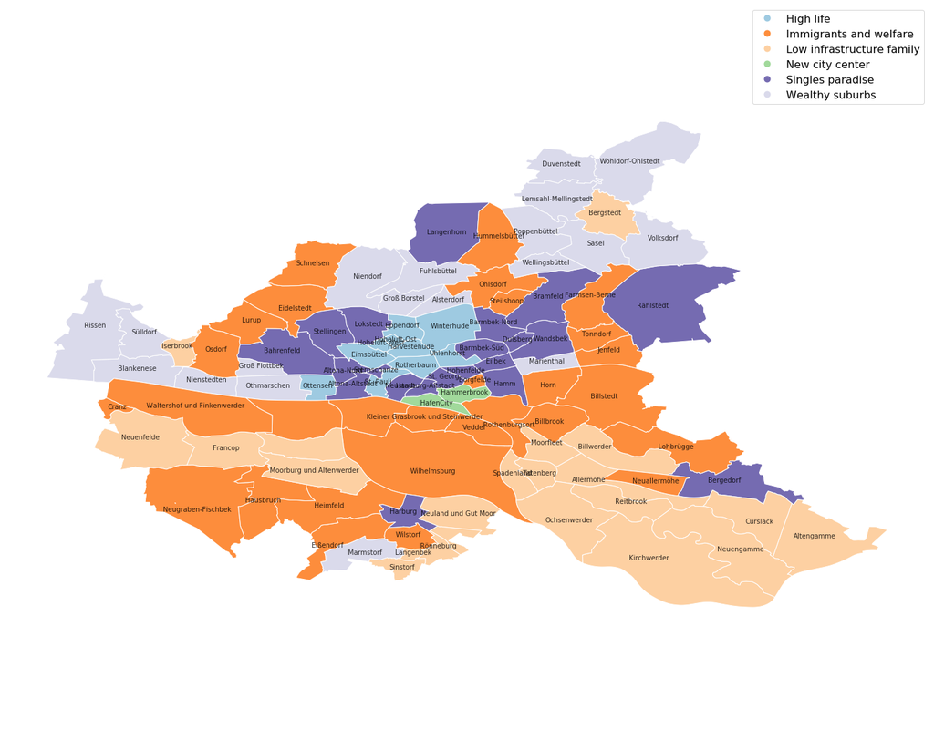